# Practica 01

```r
install.packages("norm2")
```

```r
library(norm2)
data(flas)
```

```r
flas$FLAS
```

```
  [1] 32 28 28 13 26 22 NA NA 23 10 20 NA 23 26 13 23 20 25 24 29 24 NA 23 19 16 20 24 12 35 23 19  9 14 32 NA 33 22 33 17 26 21 NA
 [43] 25 21 28 25 30 NA NA 21 24 23 27 13 NA 19 19 17 22 27 23 27 NA NA 16 17 15 27 22 20 28 39 NA 29 37 18 37 NA 34 17 NA NA 23 29
 [85] 38 27 NA 25 26 22 NA 28 22 32 32 23 NA 21 NA 19 NA 24 29 16 22 15 36 36 23 32 30 16 NA 22 20 NA NA 20 NA 27 18 19 26 19 34 25
[127] 27 18 26 15 33 27 37 31 33 27 NA 29 22 25 20 NA 25 NA 19 26 NA 21 22 22 36 NA 14 24 23 28 27 28 30 28 NA 15 29 25 24 NA NA NA
[169] 35 19 18 28 32 20 23 18 16 40 NA 28 26 19 30 26 19 28 19 NA 26 20 26 26 19 28 23 24 24 38 16 18 21 27 30 28 32 29 23 18 NA 40
[211] NA 27 16 NA 25 29 25 13 16 22 32 NA 17 22 NA 13 26 NA 17 23 27 32 33 26 20 17 24 23 17 19 23 34 NA 25  9 24 25 36 24 NA 31 31
[253] 32 26 13 27 22 29 20 24 34 NA 28 21 18 29 30 NA NA NA 17 NA 30 NA 26 22 24 21 17
```

# Pregunta 1

El conjunto de datos flas de la librería norm2 contiene datos de un estudio para evaluar la confiabilidad de la Escala de actitud de lenguaje extranjero, un instrumento para predecir el éxito en el estudio de idiomas extranjeros (Raymond y Roberts, 1983). El cuestionario se entregó a 279 estudiantes matriculados en cuatro cursos de idiomas diferentes (francés, alemán, español, ruso) en la Universidad Penn State. Este conjunto de datos incluye el puntaje FLAS, la calificación final en el curso y otras variables para predecir el logro. Para mayores detalles consultar la ayuda en R. Realice un diagnóstico de datos perdidos y responda:

## (a) ¿Cuantas filas con valores perdidos hay en el conjunto de datos?

Para ver la cantidad datos perdidos

```r
fila.perdidas <- which(rowSums(is.na(flas))!=0)
length(fila.perdidas)
```

```
[1] 105
```

## (a) ¿Qué porcentaje de todos los valores es?

```r
(length(fila.perdidas)/dim(flas)[1]) * 100
```

```
[1] 37.63441
```

El 37.63 % de filas son datos perdidos

## (b) ¿Cuantos atributos (columnas) hay sin ningún dato perdido?

```r
which(colSums(is.na(flas))!=0)
```

```
 AGE  PRI  SEX FLAS SATV SATM  ENG HGPA CGPA  GRD
   4    5    6    8    9   10   11   12   13   14
```

En total hay 10 atributos que tienen datos perdidos

## (b) Describa la cantidad y el porcentaje de datos

```r
colmiss=c(4,5,6,8,9,10,11,12,13,14)
per.miss.col=100*colSums(is.na(flas[,colmiss]))/dim(flas)[1]
per.miss.col
```

```
       AGE        PRI        SEX       FLAS       SATV       SATM        ENG
 3.9426523  3.9426523  0.3584229 17.5627240 12.1863799 12.1863799 13.2616487
      HGPA       CGPA        GRD
 0.3584229 12.1863799 16.8458781
```

Se ve que la columna AGE tiene 3.94% Se ve que la columna PRI tiene 3.94% Se ve que la columna SEX tiene 0.36% Se ve que la columna FLAS tiene 17.56% Se ve que la columna SATV tiene 12.19% Se ve que la columna SATM tiene 12.194% Se ve que la columna ENG tiene 13.264% Se ve que la columna HGPA tiene 0.36% Se ve que la columna CGPA tiene 12.194% Se ve que la columna GRD tiene 16.84%

## (c) ¿Cuantos patrones de datos perdidos distintos presenta el conjunto de datos?

```
not enough horizontal space to display frequencies
```

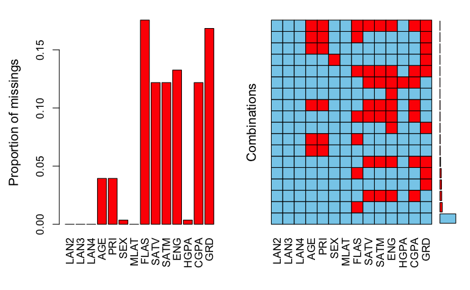

```r
library(ranger)
library(laeken)
library(robustbase)
library(VIM)
# Aggregation plot
a=aggr(flas,numbers=T)
```

```r
summary(a)
```

```
 Missings per variable:
```

|  | Variable | Count |
| --- | --- | --- |
| LAN2 | LAN2 | 0 |
| LAN3 | LAN3 | 0 |
| LAN4 | LAN4 | 0 |
| AGE | AGE | 11 |
| PRI | PRI | 11 |
| SEX | SEX | 1 |
| MLAT | MLAT | 0 |
| FLAS | FLAS | 49 |
| SATV | SATV | 34 |
| SATM | SATM | 34 |

[output cut: 4 more lines]

```
 Missings in combinations of variables:
```

| Combinations | Count | Percent |
| --- | --- | --- |
| 0:0:0:0:0:0:0:0:0:0:0:0:0:0 | 174 | 62.3655914 |
| 0:0:0:0:0:0:0:0:0:0:0:0:0:1 | 18 | 6.4516129 |
| 0:0:0:0:0:0:0:0:0:0:1:0:0:0 | 1 | 0.3584229 |
| 0:0:0:0:0:0:0:0:0:0:1:0:0:1 | 2 | 0.7168459 |
| 0:0:0:0:0:0:0:0:1:1:1:0:1:0 | 20 | 7.1684588 |
| 0:0:0:0:0:0:0:0:1:1:1:0:1:1 | 7 | 2.5089606 |
| 0:0:0:0:0:0:0:0:1:1:1:1:1:0 | 1 | 0.3584229 |
| 0:0:0:0:0:0:0:1:0:0:0:0:0:0 | 26 | 9.3189964 |
| 0:0:0:0:0:0:0:1:0:0:0:0:0:1 | 15 | 5.3763441 |
| 0:0:0:0:0:0:0:1:1:1:1:0:1:0 | 2 | 0.7168459 |

[output cut: 8 more lines]

## (c)¿Cuál es el que ocurre con mayor frecuencia? Justifique su respuesta usando una gráfica apropiada

```
not enough horizontal space to display frequencies
```

```
 Variables sorted by number of missings:
```

| Variable | Count |
| --- | --- |
| FLAS | 0.175627240 |
| GRD | 0.168458781 |
| ENG | 0.132616487 |
| SATV | 0.121863799 |
| SATM | 0.121863799 |
| CGPA | 0.121863799 |
| AGE | 0.039426523 |
| PRI | 0.039426523 |
| SEX | 0.003584229 |
| HGPA | 0.003584229 |

[output cut: 4 more lines]

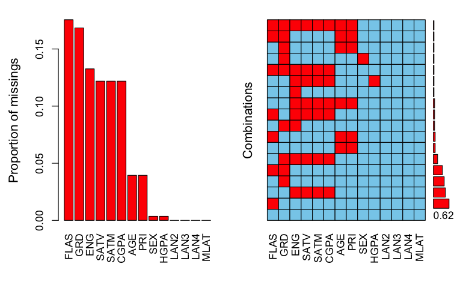

```r
aggr(flas,numbers=T, sortComb=TRUE, sortVar=TRUE, only.miss=TRUE)
```

3. ¿Cuantos patrones de datos perdidos distintos presenta el conjunto de datos?

Se observa que hay filas que tienen 1,2,3,4,5,6 y 8 atributos faltante Tengo un 627% de filas completas

(c)¿Cuál es el que ocurre con mayor frecuencia? Justifique su respuesta usando una gráfica apropiada

Tengo un 18% que tiene datos faltantes para la variable FLAS Tengo un 17% que tiene datos faltantes para la variable GRD Tengo un 13% que tiene datos faltantes para la variable ENG Tengo un 12.5% que tiene datos faltantes para la variable SATV Tengo un 12.5% que tiene datos faltantes para la variable SATM Tengo un 12.5% que tiene datos faltantes para la variable CGPA Tengo un 4% que tiene datos faltantes para la variable AGRE Tengo un 4% que tiene datos faltantes para la variable PRI Tengo un 0.5% que tiene datos faltantes para la variable SEX Tengo un 0.5% que tiene datos faltantes para la variable HGPA

## (d) ¿Es posible identificar algún patrón de datos perdidos? (por ejemplo, la perdida de información en alguna variable parece estar asociada a otra.) Justifique su respuesta

```
Click in a column to sort by the corresponding variable.
To regain use of the VIM GUI and the R console, click outside the plot region.
```

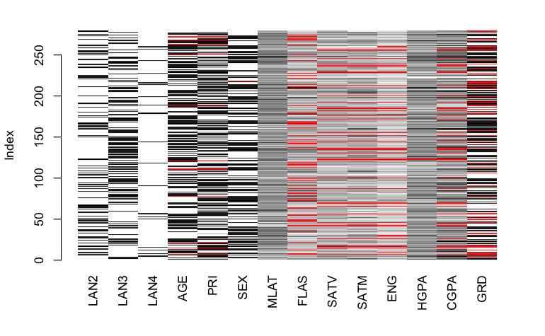

```r
# Matrix plot
matrixplot(flas)
```

Tengo un 18% que tiene datos faltantes para la variable FLAS Tengo un 17% que tiene datos faltantes para la variable GRD Tengo un 13% que tiene datos faltantes para la variable ENG Tengo un 12.5% que tiene datos faltantes para la variable SATV Tengo un 12.5% que tiene datos faltantes para la variable SATM Tengo un 12.5% que tiene datos faltantes para la variable CGPA Tengo un 4% que tiene datos faltantes para la variable AGRE Tengo un 4% que tiene datos faltantes para la variable PRI

## (e) Se desea realizar la imputación de la variable FLAS. Identifique a qué tipo de mecanismo se puede atribuir la presencia de datos perdidos. Justifique su respuesta usando técnicas de visualización y la prueba estadísticat. Luego, sobre la base del mecanismo identificado, realice la imputación de los datos perdidos

```
Click in in the left margin to switch to the previous variable or in the right margin to switch to the next variable.
To regain use of the VIM GUI and the R console, click anywhere else in the graphics window.
```

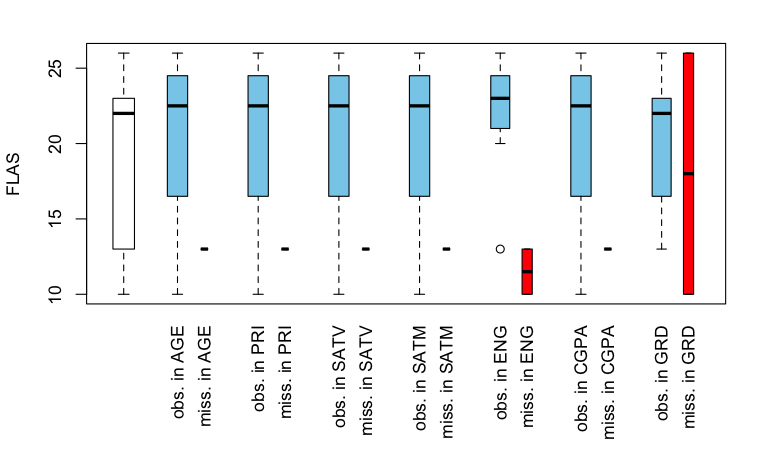

```r
#Parallel boxplots
VIM::pbox(flas[4:15,], pos=8)  # la varable de salida es el FLAS
```

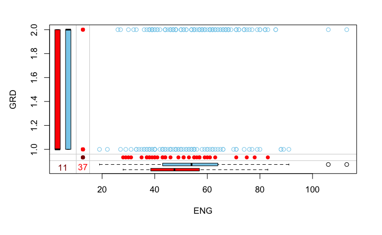

```r
marginplot(flas[,c("ENG", "GRD")])
```

# Supuestos para hacer la prueba de medias

- Los valores deben ser obtenidos datos aleatorios
- Deben venir de una distribucion normal

```r
# Prueba t de medias
t.test(FLAS ~ is.na(ENG), data=flas)
```

```
    Welch Two Sample t-test

data:  FLAS by is.na(ENG)
t = 5.3669, df = 53.534, p-value = 1.76e-06
alternative hypothesis: true difference in means is not equal to 0
95 percent confidence interval:
 3.090576 6.777752
sample estimates:
mean in group FALSE  mean in group TRUE
           24.96447            20.03030
```

Como el p es casi cero, se tiene evidencia para descartar la hipotesis nula , por lo tanto podemos asumir que la medias son distintas y se acepta el mecanismo MAR

```r
# Prueba t de medias
t.test(FLAS ~ is.na(GRD), data=flas)
```

```
    Welch Two Sample t-test

data:  FLAS by is.na(GRD)
t = 3.302, df = 36.651, p-value = 0.002148
alternative hypothesis: true difference in means is not equal to 0
95 percent confidence interval:
 1.545674 6.459473
sample estimates:
mean in group FALSE  mean in group TRUE
           24.76119            20.75862
```

```r
library(simputation)
flas.i <- impute_lm(flas, ENG + GRD ~ 1)
flas.j <- impute_lm(flas.i, FLAS ~ ENG + GRD, add_residual = "normal")
flas[c(7,8,12),]$FLAS
```

```
[1] NA NA NA
```

```r
flas.j[c(7,8,12),]$FLAS
```

```
[1] 34.78877 19.05100 19.05824
```

```r
#flas.i[c(108:110, 463,551:552),]
```